# Avaliação Final da Disciplina de Aprendizado de Máquina com R

Paulo Correa e Juliana Silvani

06/12/2021

[figure not shown]

## Origem dos Dados

Os dados foram importados da Secretaria Estadual de Saúde e do IBGE. Para fins de avaliação da capacidade vacinal dos municípios, foi utilizada a tabela de distribuição de doses de vacinas, disponível em https://vacina.saude.rs.gov.br/api/distribuicao, e a tabela sobre vacinação disponível em https://vacina.saude.rs.gov.br/api/aplicacao. Além disso, foi utilizada tabela sobre informações das medidas adotadas para combate da pandemia de COVID 19 dos municípios do Rio Grande do Sul, disponíveis no sítio do IBGE https://ftp.ibge.gov.br/Perfil_Municipios/2020/Base_de_Dados/Base_MUNIC_2020.xlsx.

```
## i Using "','" as decimal and "'.'" as grouping mark. Use `read_delim()` for more control.
```

```
## i Using "','" as decimal and "'.'" as grouping mark. Use `read_delim()` for more control.
```

## Misturando tabelas para análise

Para fins de análise, novas tabelas foram criadas a partir daquelas importadas do portal da Secretaria de Saúde, unificando-se os nomes dos municípios às tabelas com dados de distribuição e vacinação. Dados da organização das cidades para enfrentamento da COVID-19 de 2020 foram adiconados aos dados das distribuições de vacinas e aplicação. Posteriormente foi calculado a média das porporções de doses aplicadas de vacina por mês em 2021, baseadas nas doses recebidas até o início de cada mês. Desta forma, foi possível resumir uma tabela com as doses recebidas no mês e o percentual aplicado das doses totais disponíveis no município naquele mês. Consideramos que municípios que tivessem adotado medidas mais completas de combate ao COVID, talvez possuam maior capacidade de orgarnizar-se contra a pandemia e isto pode resultar em taxas vacinais maiores, sendo estas medidas capazes de predizer a capacidade vacinal.

#Importação do banco de dados de informação do combate ao COVID-19 adotado pelos municípios em 2020 As variáveis do banco de combate ao COVID 19 foram as seguintes: – Medidas de isolamento social e barreiras sanitárias  
– Foi adotada, por conta da pandemia da COVID-19, alguma medida de isolamento social no município  
– Mês de edição do decreto  
– Utilizou algum sistema de monitoramento para avaliar a eficácia do isolamento social  
– Foram instaladas barreiras sanitárias nas entradas do município durante o período da pandemia da COVID-19  
– Ações realizadas nas barreiras  
– Informativa, com distribuição de folhetos sobre o COVID-19, principais sintomas, como é transmitido e como se proteger  
– Motoristas e passageiros são questionados sobre local de origem, qual o destino, a condição de saúde com a temperatura corporal aferida e os casos considerados suspeitos são repassados para acompanhamento nas unidades de saúde  
– Não permitem a entrada de pessoas que não comprovaram residência ou trabalho em área essencial  
– Outras ações – Não sabe informar  
– Adotou alguma medida para regulamentar sanções (multas, realização compulsória de exames etc.) em caso de desrespeito as normas de isolamento social  
– Realizou a desinfecção de bairros e locais públicos do município  
– Distribuiu máscaras para a população em locais públicos  
– Adotou o uso obrigatório de máscaras em transportes públicos, locais públicos e comércios  
– Recomendou o uso de máscaras em transportes públicos, locais públicos e comércios  
– Ampliou os serviços on-line para atender a população  
– Antecipou o 13º salário dos servidores  
– Realizou testagem da população para a COVID-19  
– Adquiriu testes para testagem da população para a COVID-19  
– Fez seleção pública em caráter de urgência para profissionais de saúde que atuaram no combate ao COVID-19  
– Distribuiu cestas básicas ou crédito alimentar para as famílias de estudantes matriculados na rede pública municipal e creches parceiras  
– Mesmo com as escolas da rede pública fechadas, manteve o funcionamento dos refeitórios com o intuito de ofertar merenda para os alunos matriculados  
– Realizou operação de fiscalização de preços de produtos utilizados como prevenção ao coronavírus como álcool em gel e máscaras  
– “Suspendeu a cobrança da dívida ativa, incluindo certidões de dívida ativa, atos de ajuizamento de execuções financeiras e atos de inscrição de dívida ativa”  
– Outras ações  
– Não realizou nenhuma ação relacionada a pandemia da COVID-19

– Distribuiu kits de higiene (álcool em gel, papel higiênico, sabonete, creme dental e escovas de dentes)  
– Distribuiu kits de limpeza (sacos de lixo, sabão em pedra, água sanitária ou desinfetante)  
– Distribuiu máscaras  
– Distribuiu cestas básicas ou crédito alimentar para as famílias que recebem Bolsa Família  
– Distribuiu cestas básicas ou crédito alimentar para a população que foi atingida economicamente pela pandemia e não estava inscrita no Bolsa Família  
– Criou locais emergenciais (com oferta de refeições, higienização, triagem médica e atendimento psicossocial) de acolhimento provisório para a população em situação de rua  
– Ofertou espaços descentralizados de higienização para a população em situação de rua  
– Criou pontos de acolhimento para a população em situação de rua  
– Organizou pontos de recebimento de doações de alimentos, roupas, produtos de higiene, produtos de limpeza e outros  
– Cadastrou famílias e indivíduos no Cadastro Único e Programa Bolsa Família para acesso aos programas sociais e de proteção social  
– Cadastrou indivíduos para recebimento do auxílio emergencial do governo federal  
– Cadastrou indivíduos para recebimento do auxílio emergencial concedido pelo município  
– Ampliou a cobertura para concessão de benefícios eventuais  
– Viabilizou a concessão de benefícios eventuais para a população atingida economicamente pela pandemia  
– Viabilizou a manutenção do funcionamento dos CRAS e CREAS  
– Garantiu a manutenção do funcionamento das unidades de acolhimento municipais, independente do público atendido  
– Garantiu a manutenção do funcionamento com atenção redobrada para as instituições de longa permanência para idosos  
– Garantiu a continuidade de atendimentos aos doentes crônicos monitorando este grupo em especial por conta das vulnerabilidades e risco aumentado  
– Monitorou violência doméstica e outros tipos de violência durante a pandemia  
– Manteve as Unidades do Centro de Atenção Psicossocial (CAPS) em funcionamento  
– Outras ações  
– Não realizou nenhuma ação relacionada a pandemia da COVID-19  
– Ocorreram casos confirmados clinicamente ou laboratorialmente de COVID-19 no município  
– Houve a instalação de tendas de triagem para o combate da COVID-19, no município  
– Dentre as pessoas que contraíram a COVID-19, houve alguma com necessidade de internação  
– O número de internações ultrapassou a capacidade de leitos e de unidades de tratamento intensivo (UTI) públicos ou privados conveniados ao SUS, existentes no município durante a pandemia da COVID-19?  
– O número de leitos foi ampliado para atender à demanda por internação no município em virtude da COVID-19  
– A ampliação de leitos se deu por meio de  
– Ampliação de estrutura própria  
– Pactuação com outro município  
– Pactuação com o estado  
– Pactuação com o governo federal  
– Contratação de leitos privados  
– Não sabe informar  
– Foi instalado hospital de campanha durante a pandemia da COVID-19 no município  
– Nos casos de internação por COVID-19, houve necessidade de referenciar o(s) paciente(s) para outro município  
– Durante o período da pandemia do COVID-19 foi necessário manter pessoas por mais de 24 horas em unidades sem internação  
– Dentre as pessoas que contraíram a COVID-19, ocorreu algum óbito  
– O município adotou alguma medida de rodízio na circulação de automóveis, motocicletas, ônibus ou outro transporte público ou privado no período da pandemia da COVID-19

#Modelagem da predição de percentual de vacinados

```r
library(modelr)
library(tidyr)
library(dplyr)
library(readr)

options(na.action = na.warn)
```

#Importação da tabela condensada

```r
tabela_modelo<- read_csv("tabela_final2.csv") %>% select(-c(CD_MUNICIPIO, NOME))
```

#Função para converter os valores que não estão entre 0-1 para valores entre 0-1

```r
intervalo01<- function(x){
  (x-min(x))/(max(x)-min(x))}
```

#Importa a tabela condensada, exclui as linhas com dados faltantes e coloca valores grandes entre 0-1

```r
tabela_modelo <- tabela_modelo %>%
  drop_na() %>%
  mutate(POPULACAO = intervalo01(POPULACAO),
            MEDIA_DOSES_RECEBIDAS = intervalo01(MEDIA_DOSES_RECEBIDAS),
            Mes_decreto_medida = intervalo01(Mes_decreto_medida))

tabela_modelo
```

```
## # A tibble: 89 x 73
##    POPULACAO MEDIA_DOSES_RECEBIDAS PERCENTUAL_MEDIO_A~ SEXO_FEMININO RACA_BRANCA
##        <dbl>                 <dbl>               <dbl>         <dbl>       <dbl>
##  1   0.00609               0.00582               0.907         0.558       0.918
##  2   0.605                 0.519                 0.869         0.580       0.636
##  3   0.0141                0.0148                0.916         0.563       0.958
##  4   0.0252                0.0276                0.905         0.566       0.876
##  5   0.0490                0.0463                0.891         0.556       0.783
##  6   0.347                 0.328                 0.863         0.587       0.670
##  7   0.0368                0.0337                0.821         0.549       0.770
##  8   0.00547               0.00334               0.917         0.552       0.900
##  9   0.0155                0.0148                0.883         0.566       0.955
## 10   0.0368                0.0311                0.897         0.564       0.954
## # ... with 79 more rows, and 68 more variables:
## #   Nao_adotou_medidas_isolamento <lgl>,
## #   Orientou_populacao_ficar_em_casa <lgl>, Decretou_isolamento_social <lgl>,
## #   Mes_decreto_medida <dbl>, Monitoriza_isolamento <lgl>,
## #   Barreira_sanitaria <lgl>, Acao_barreira_informativa <lgl>,
## #   Acao_barreira_local_origem <lgl>, Acao_barreira_proibe_entrada <lgl>,
## #   Acao_barreira_outra <lgl>, Acao_barreira_nao_sabe <lgl>, ...
```

```r
library(caret)
library(glmnet)
library(leaps)
library(ggpubr)
```

#Particiona a tabela de dados entre conjunto de teste e treinamento

```r
sample <- sample.int(n = nrow(tabela_modelo), size = floor(.75*nrow(tabela_modelo)), replace = F)
treinamento <- tabela_modelo[sample, ]
teste  <- tabela_modelo[-sample, ]
```

#Resumo dos modelos

```
##
## Call:
## lm(formula = PERCENTUAL_MEDIO_APLICADO ~ POPULACAO + MEDIA_DOSES_RECEBIDAS +
##     SEXO_FEMININO + RACA_BRANCA + Mes_decreto_medida + Monitoriza_isolamento +
##     Acao_barreira_informativa + Acao_barreira_local_origem +
##     Acao_barreira_proibe_entrada + Acao_barreira_outra + Não_regulamenta_sancao +
##     Regulamenta_sancao_cidadaos_estabelecimentos + Desinfeccao_publica +
##     Distribuiu_mascaras_local_publico + Mascara_obrigatoria_publico +
##     Servico_online_populacao + Antecipou_13_salario + Realizou_teste_covid19 +
##     Adquiriu_teste_covid19 + Distribuiu_cesta_basica_estudante +
##     Refeitorio_escola_fechada + Fiscalizou_preco_EPI + Suspendeu_cobranca_divida +
##     Realizou_outras_acoes_preventivas + Distribuiu_kit_higiene +
##     Distribuiu_kit_limpeza + Distribuiu_mascaras + Distribuiu_cesta_basica_bolsa_familia +
##     Distribuiu_cesta_basica_atingidos + Criou_locais_emergenciais +
##     Espacos_higienizacao_populacao_rua + Criou_acolhimento_populacao_rua +
##     Pontos_recolhimento_doacoes + Cadastrou_familias_CadUn_BolFam +
##     Cadastrou_auxilio_emergencial_federal + Cadastrou_auxilio_emergencial_municipio +
##     Ampliou_cobertura_beneficios + Viabilizou_beneficios_eventuais +
##     Manteve_CRAS_CREAS + Manteve_acolhimento_municipio + Manteve_instituicao_longa_perm +
##     Manteve_cuidado_doente_cronico + Manteve_CAPS + Outras_acoes_sociais +
##     Instalacao_tendas + Internacao_ultrapassou_capacidade + Ampliacao_leitos_estrutura_propria +
##     Ampliacao_leitos_pactuacao_intermunicipal + Ampliacao_leitos_pactuacao_estado +
##     Ampliacao_leitos_federal + Ampliacao_leitos_privados + Nao_sabe_informar_ampliacao_leitos +
##     Hospital_campanha + Encaminhou_paciente + Manteve_pacientes_sem_internacao +
##     Obito_por_Covid + Rodizio_automoveis, data = treinamento)
##
## Residuals:
##        Min         1Q     Median         3Q        Max
## -0.0178450 -0.0044656  0.0000272  0.0057401  0.0136328
##
## Coefficients:
##                                                   Estimate Std. Error t value
## (Intercept)                                       1.918302   0.256947   7.466
## POPULACAO                                        -3.849477   1.133898  -3.395
## MEDIA_DOSES_RECEBIDAS                             3.737728   1.131240   3.304
## SEXO_FEMININO                                    -2.986553   0.577895  -5.168
## RACA_BRANCA                                       0.808319   0.153189   5.277
## Mes_decreto_medida                                0.057763   0.029646   1.948
## Monitoriza_isolamentoTRUE                         0.121423   0.026716   4.545
## Acao_barreira_informativaTRUE                     0.023535   0.018328   1.284
```

[output cut: 100 more lines]

```
## Ampliacao_leitos_pactuacao_estadoTRUE            0.093856 .
## Ampliacao_leitos_federalTRUE                     0.003023 **
## Ampliacao_leitos_privadosTRUE                    0.179095
## Nao_sabe_informar_ampliacao_leitosTRUE           0.037560 *
## Hospital_campanhaTRUE                            0.027123 *
## Encaminhou_pacienteTRUE                          0.078374 .
## Manteve_pacientes_sem_internacaoTRUE             0.070631 .
## Obito_por_CovidTRUE                              0.001334 **
## Rodizio_automoveisTRUE                           0.003055 **
## ---
## Signif. codes:  0 '***' 0.001 '**' 0.01 '*' 0.05 '.' 0.1 ' ' 1
##
## Residual standard error: 0.02052 on 8 degrees of freedom
## Multiple R-squared:  0.9805, Adjusted R-squared:  0.8415
## F-statistic: 7.056 on 57 and 8 DF,  p-value: 0.003173
```

```
##
## Call:
## lm(formula = PERCENTUAL_MEDIO_APLICADO ~ POPULACAO + MEDIA_DOSES_RECEBIDAS +
##     SEXO_FEMININO + RACA_BRANCA + Nao_adotou_medidas_isolamento +
##     Orientou_populacao_ficar_em_casa + Decretou_isolamento_social +
##     Mes_decreto_medida + Monitoriza_isolamento + Barreira_sanitaria +
##     Acao_barreira_informativa + Acao_barreira_local_origem +
##     Acao_barreira_proibe_entrada + Acao_barreira_outra + Acao_barreira_nao_sabe +
##     Regulamenta_sancao_cidadaos + Não_regulamenta_sancao + Regulamenta_sancao_cidadaos_estabelecimentos +
##     Regulamenta_sancao_estabelecimentos + Desinfeccao_publica +
##     Distribuiu_mascaras_local_publico + Mascara_obrigatoria_publico +
##     Mascara_recomendada_pulbico + Servico_online_populacao +
##     Antecipou_13_salario + Realizou_teste_covid19 + Adquiriu_teste_covid19 +
##     Selecao_urgente_saude + Distribuiu_cesta_basica_estudante +
##     Refeitorio_escola_fechada + Fiscalizou_preco_EPI + Suspendeu_cobranca_divida +
##     Realizou_outras_acoes_preventivas + Nao_realizou_acoes_em_geral +
##     Distribuiu_kit_higiene + Distribuiu_kit_limpeza + Distribuiu_mascaras +
##     Distribuiu_cesta_basica_bolsa_familia + Distribuiu_cesta_basica_atingidos +
##     Criou_locais_emergenciais + Espacos_higienizacao_populacao_rua +
##     Criou_acolhimento_populacao_rua + Pontos_recolhimento_doacoes +
##     Cadastrou_familias_CadUn_BolFam + Cadastrou_auxilio_emergencial_federal +
##     Cadastrou_auxilio_emergencial_municipio + Ampliou_cobertura_beneficios +
##     Viabilizou_beneficios_eventuais + Manteve_CRAS_CREAS + Manteve_acolhimento_municipio +
##     Manteve_instituicao_longa_perm + Manteve_cuidado_doente_cronico +
##     Monitorou_violencia_domestica + Manteve_CAPS + Outras_acoes_sociais +
##     Nao_realizou_acoes_sociais + Ocorreram_casos_Covid + Instalacao_tendas +
##     Internacao_paciente_Covid + Internacao_ultrapassou_capacidade +
##     Internacao_ampliou_leitos + Ampliacao_leitos_estrutura_propria +
##     Ampliacao_leitos_pactuacao_intermunicipal + Ampliacao_leitos_pactuacao_estado +
##     Ampliacao_leitos_federal + Ampliacao_leitos_privados + Nao_sabe_informar_ampliacao_leitos +
##     Hospital_campanha + Encaminhou_paciente + Manteve_pacientes_sem_internacao +
##     Obito_por_Covid + Rodizio_automoveis, data = treinamento)
##
## Residuals:
##          1          2          3          4          5          6          7
##  7.915e-05 -3.944e-03 -1.310e-02 -5.937e-03  1.922e-03 -1.216e-02 -1.622e-02
##          8          9         10         11         12         13         14
## -5.707e-03  2.985e-18  8.729e-03 -8.399e-03  5.287e-03 -1.832e-03 -1.798e-03
##         15         16         17         18         19         20         21
##  3.428e-03  2.023e-03 -1.368e-02  6.729e-03  5.209e-03 -1.182e-03 -1.061e-03
```

[output cut: 155 more lines]

```
## Ampliacao_leitos_pactuacao_estadoTRUE             0.36027
## Ampliacao_leitos_federalTRUE                      0.07922 .
## Ampliacao_leitos_privadosTRUE                     0.38265
## Nao_sabe_informar_ampliacao_leitosTRUE            0.33675
## Hospital_campanhaTRUE                             0.24090
## Encaminhou_pacienteTRUE                           0.31579
## Manteve_pacientes_sem_internacaoTRUE              0.28314
## Obito_por_CovidTRUE                               0.05877 .
## Rodizio_automoveisTRUE                            0.07436 .
## ---
## Signif. codes:  0 '***' 0.001 '**' 0.01 '*' 0.05 '.' 0.1 ' ' 1
##
## Residual standard error: 0.02859 on 4 degrees of freedom
## Multiple R-squared:  0.9811, Adjusted R-squared:  0.6925
## F-statistic:   3.4 on 61 and 4 DF,  p-value: 0.1193
```

#Plots dos modelos

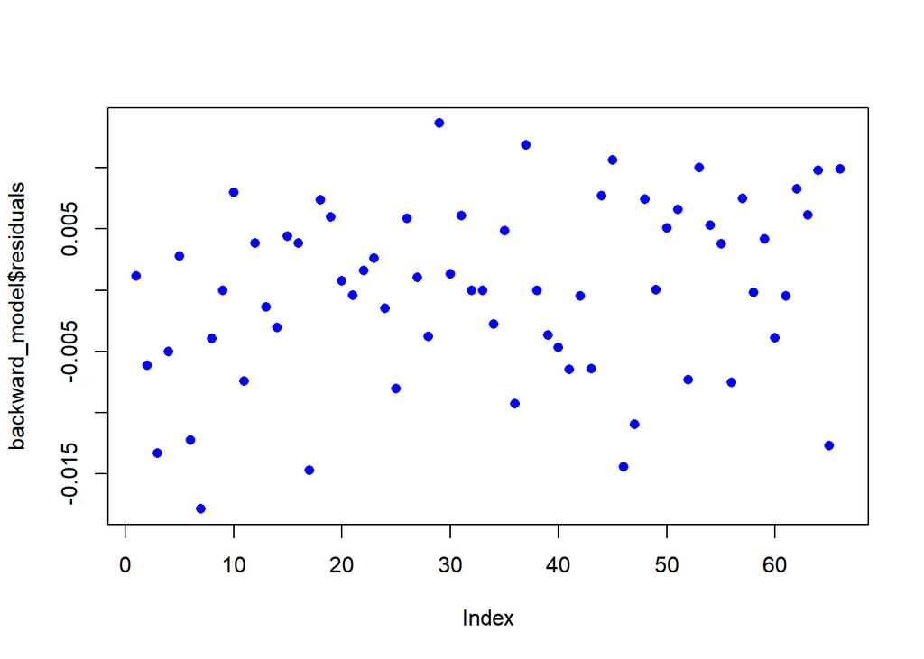

```r
plot(backward_model$residuals,pch = 16, col = "blue")
```

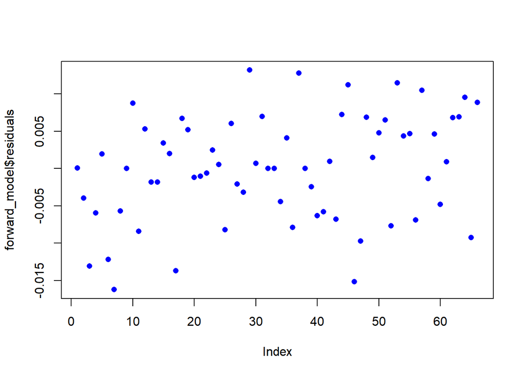

```r
plot(forward_model$residuals,pch = 16, col = "blue")
```

#Predição

```r
predicao1 <-predict(backward_model, newdata = teste, interval = "prediction")
predicao2 <-predict(forward_model, newdata = teste, interval = "prediction")
```

#Gráfico das predições diferentes métdos de regressão linear do modelo

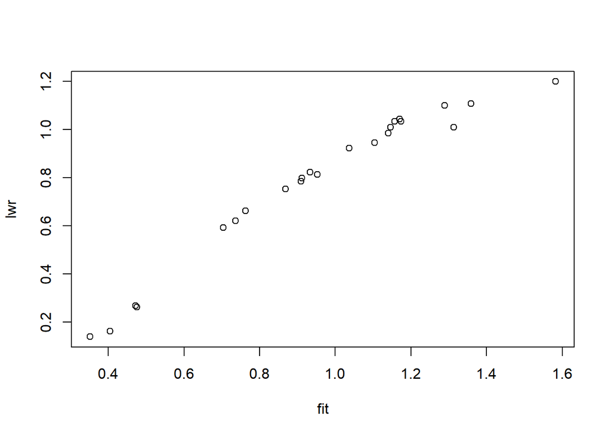

```r
plot(predicao1)
```

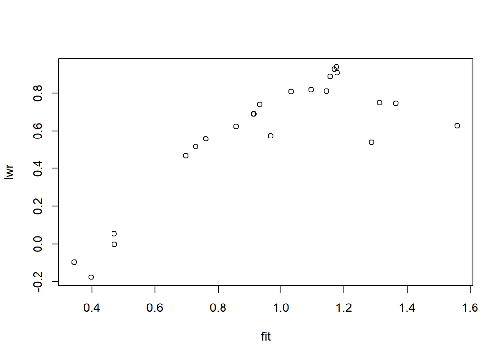

```r
plot(predicao2)
```

#Tabela com os valores preditos e o IC95%

```r
predicao1
```

```
##          fit       lwr       upr
## 1  0.7034562 0.5924580 0.8144543
## 2  0.4714410 0.2668250 0.6760570
## 3  1.3129867 1.0106108 1.6153627
## 4  0.9528917 0.8130080 1.0927755
## 5  0.7361798 0.6201125 0.8522472
## 6  1.1038939 0.9464413 1.2613464
## 7  1.2890706 1.0999362 1.4782050
## 8  1.1704351 1.0443622 1.2965080
## 9  0.4052892 0.1624310 0.6481474
## 10 0.8689268 0.7532833 0.9845703
## 11 1.5820472 1.1997382 1.9643562
## 12 1.1463193 1.0099653 1.2826733
## 13 0.7626255 0.6618990 0.8633520
## 14 1.0371466 0.9228114 1.1514818
## 15 1.1399742 0.9861405 1.2938080
## 16 1.3586500 1.1082717 1.6090284
## 17 1.1567847 1.0341506 1.2794188
## 18 0.3517249 0.1388776 0.5645721
## 19 0.4758340 0.2620304 0.6896375
## 20 0.9094669 0.7845796 1.0343542
## 21 0.9339274 0.8233587 1.0444962
## 22 1.1732733 1.0339052 1.3126413
## 23 0.9120459 0.7992295 1.0248623
```

```r
predicao2
```

```
##          fit          lwr       upr
## 1  0.6970179  0.468515655 0.9255201
## 2  0.4712297 -0.002094887 0.9445542
## 3  1.2873027  0.538596141 2.0360093
## 4  0.9670392  0.573571422 1.3605069
## 5  0.7284858  0.516445314 0.9405263
## 6  1.0963702  0.818424297 1.3743161
## 7  1.3124727  0.751092944 1.8738525
## 8  1.1760837  0.937966203 1.4142013
## 9  0.3978844 -0.177538806 0.9733076
## 10 0.8579008  0.623197498 1.0926041
## 11 1.5596412  0.627507833 2.4917745
## 12 1.1553749  0.889455504 1.4212944
## 13 0.7613600  0.558519665 0.9642003
## 14 1.0315016  0.807227240 1.2557760
## 15 1.1436347  0.810257918 1.4770115
## 16 1.3652461  0.745533179 1.9849591
## 17 1.1685780  0.925960536 1.4111955
## 18 0.3426753 -0.098414318 0.7837650
## 19 0.4697161  0.054082783 0.8853494
## 20 0.9120591  0.688961596 1.1351565
## 21 0.9325961  0.739437438 1.1257548
## 22 1.1780251  0.909370813 1.4466794
## 23 0.9148206  0.689050123 1.1405911
```

#Transforma o conjunto de teste e treinamento em matrizes sem a variável target

```r
train_matrix<- select(treinamento,-PERCENTUAL_MEDIO_APLICADO) %>%  as.matrix

test_matrix <- select(teste, -PERCENTUAL_MEDIO_APLICADO) %>% as.matrix
lasso<- cv.glmnet(train_matrix, treinamento$PERCENTUAL_MEDIO_APLICADO, alpha=1)
```

#Predito mínimos quadrados - penalidade Lasso Induz esparsidade em β. Modelo fácil de interpretar. Bom poder preditivo.

```r
predito_min.quadrados <- predict(lasso, s=0, newx = test_matrix)
predito_min.quadrados
```

```
##              s1
##  [1,] 0.8746769
##  [2,] 0.8509538
##  [3,] 0.9721867
##  [4,] 0.7645782
##  [5,] 0.8570997
##  [6,] 0.9926980
##  [7,] 0.9269431
##  [8,] 0.9760473
##  [9,] 0.8563768
## [10,] 0.8942411
## [11,] 1.0253271
## [12,] 1.0632443
## [13,] 0.8389499
## [14,] 0.9449524
## [15,] 0.9655806
## [16,] 0.8642335
## [17,] 0.9650221
## [18,] 0.7512502
## [19,] 0.8147942
## [20,] 0.8854865
## [21,] 0.9156339
## [22,] 1.0178246
## [23,] 0.9079033
```

```r
predito_lasso2 <- predict(lasso, s=lasso$lambda.min, newx = test_matrix)
predito_lasso2
```

```
##              s1
##  [1,] 0.8855577
##  [2,] 0.8861455
##  [3,] 0.8856386
##  [4,] 0.8862084
##  [5,] 0.8861517
##  [6,] 0.8861992
##  [7,] 0.8865162
##  [8,] 0.8839444
##  [9,] 0.8835635
## [10,] 0.8843128
## [11,] 0.8863386
## [12,] 0.8861259
## [13,] 0.8857001
## [14,] 0.8847532
## [15,] 0.8861017
## [16,] 0.8685320
## [17,] 0.8834458
## [18,] 0.8792665
## [19,] 0.8801652
## [20,] 0.8811948
## [21,] 0.8828167
## [22,] 0.8862081
## [23,] 0.8862393
```

#Penalidade Ridge Não induz esparsidade em β, mas reduz variância, pois “encolhe” o estimador.

```r
ridge<- cv.glmnet(train_matrix, treinamento$PERCENTUAL_MEDIO_APLICADO, alpha = 0)
predito_ridge<- predict(ridge, s=ridge$lambda.min, newx = test_matrix)
predito_ridge
```

```
##              s1
##  [1,] 0.8837795
##  [2,] 0.8937436
##  [3,] 0.9056916
##  [4,] 0.8836841
##  [5,] 0.8940778
##  [6,] 0.8915791
##  [7,] 0.8993164
##  [8,] 0.8896777
##  [9,] 0.8863000
## [10,] 0.8833247
## [11,] 0.9100278
## [12,] 0.8994992
## [13,] 0.8776729
## [14,] 0.8891675
## [15,] 0.8969180
## [16,] 0.8571355
## [17,] 0.8911188
## [18,] 0.8697654
## [19,] 0.8768248
## [20,] 0.8776517
## [21,] 0.8851879
## [22,] 0.9022193
## [23,] 0.8824318
```

#Plot mínimo quadrados

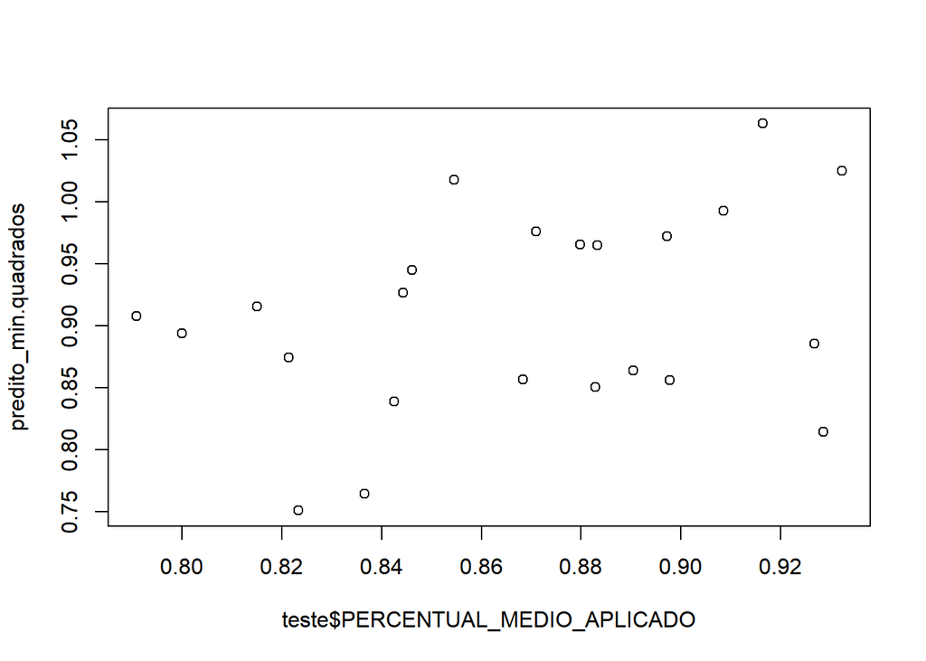

```r
plot(teste$PERCENTUAL_MEDIO_APLICADO,predito_min.quadrados)
```

#Plot Lasso

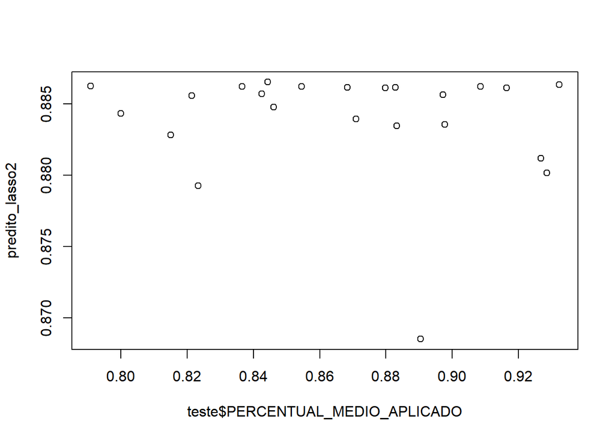

```r
plot(teste$PERCENTUAL_MEDIO_APLICADO, predito_lasso2)
```

#Plot Ridge

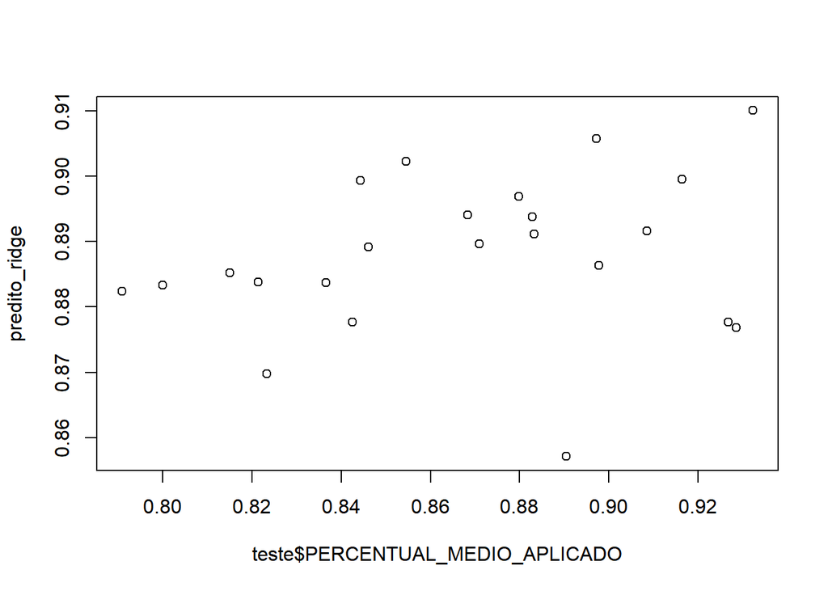

```r
plot(teste$PERCENTUAL_MEDIO_APLICADO, predito_ridge)
```

#Plota os valores mínimos para redução de erro

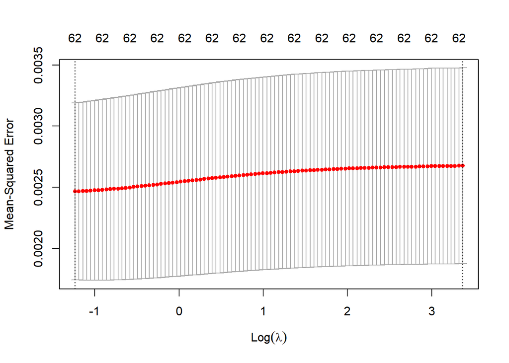

```r
p1<-plot(ridge)
```

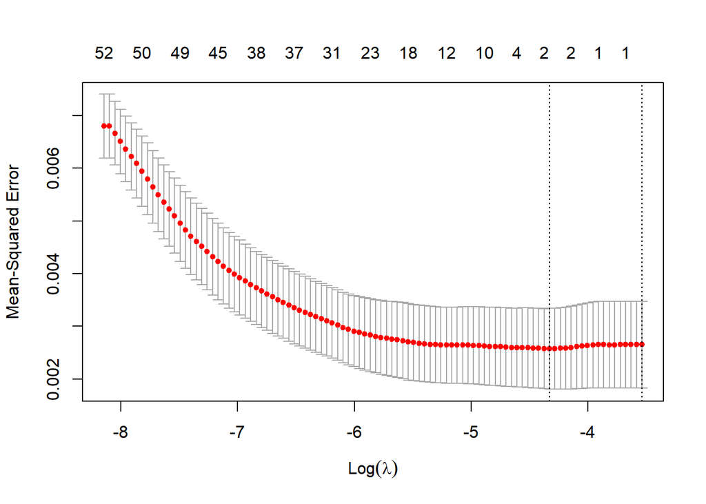

```r
p2<-plot(lasso)
```

#Cria uma lista com os erros de cada modelo para comparação

```r
riscos<- list()
riscos$minimos.quadrados<- (predito_min.quadrados-teste$PERCENTUAL_MEDIO_APLICADO)^2 %>%  mean()
riscos$ridge<- (predito_ridge-teste$PERCENTUAL_MEDIO_APLICADO)^2 %>% mean()
riscos$lasso<- (predito_lasso2-teste$PERCENTUAL_MEDIO_APLICADO)^2 %>%  mean()
riscos$backward<- (predicao1-teste$PERCENTUAL_MEDIO_APLICADO)^2 %>%  mean()
riscos$forward <- (predicao2-teste$PERCENTUAL_MEDIO_APLICADO)^2 %>%  mean()
riscos
```

```
## $minimos.quadrados
## [1] 0.007624472
##
## $ridge
## [1] 0.00199383
##
## $lasso
## [1] 0.001997665
##
## $backward
## [1] 0.1264992
##
## $forward
## [1] 0.222074
```

#Plota a feature importance dos modelos de regressão linear do modelr

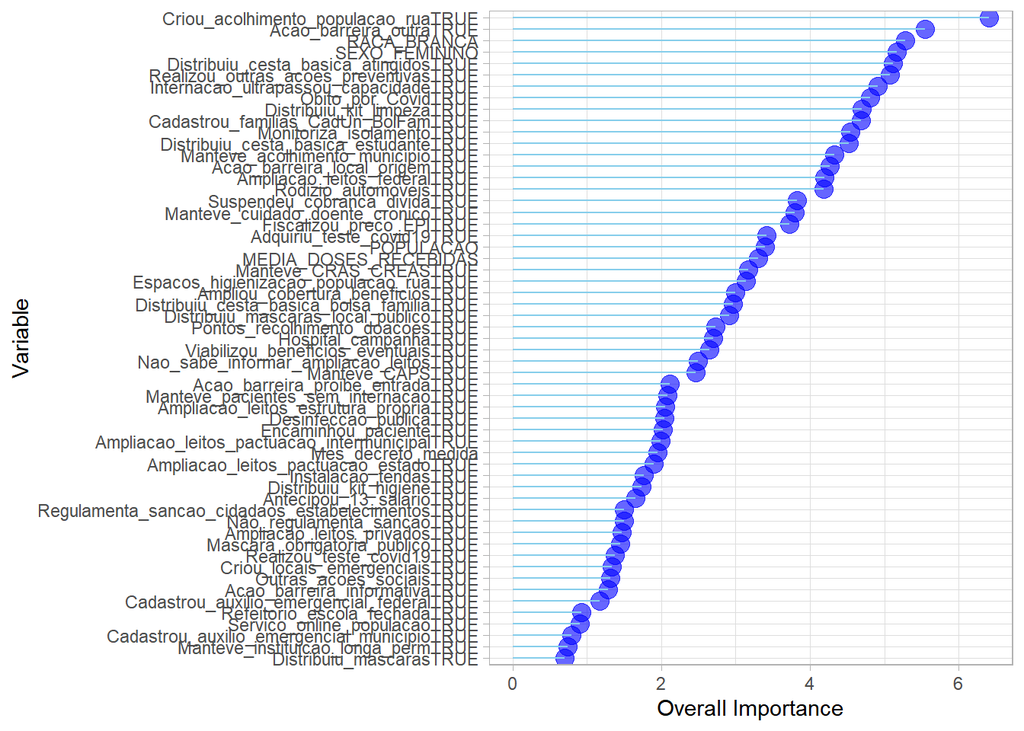

```r
Variavel_Importance_backward <- varImp(backward_model, scale=FALSE)
V = caret::varImp(backward_model)

ggplot2::ggplot(V, aes(x=reorder(rownames(V),Overall), y=Overall)) +
  geom_point( color="blue", size=4, alpha=0.6)+
  geom_segment( aes(x=rownames(V), xend=rownames(V), y=0, yend=Overall),
                color='skyblue') +
  xlab('Variable')+
  ylab('Overall Importance')+
  theme_light() +
  coord_flip()
```

#Plota a feature importance do modelo de lasso

```r
table(coef(lasso, s=lasso$lambda.min)[,1]!=0)
```

```
##
## FALSE  TRUE
##    70     3
```

```r
coefs_estimates<- coef(lasso, s= lasso$lambda.min)
coefs<- coefs_estimates %>%
  as.matrix() %>%
  as_tibble
names(coefs) = "Estimativa"
coefs %>%
  mutate(variavel = rownames(coefs_estimates)) %>%
  arrange(desc(abs(Estimativa)))
```

```
## # A tibble: 73 x 2
##    Estimativa variavel
##         <dbl> <chr>
##  1     1.01   (Intercept)
##  2    -0.127  Mascara_obrigatoria_publico
##  3    -0.0310 MEDIA_DOSES_RECEBIDAS
##  4     0      POPULACAO
##  5     0      SEXO_FEMININO
##  6     0      RACA_BRANCA
##  7     0      Nao_adotou_medidas_isolamento
##  8     0      Orientou_populacao_ficar_em_casa
##  9     0      Decretou_isolamento_social
## 10     0      Mes_decreto_medida
## # ... with 63 more rows
```

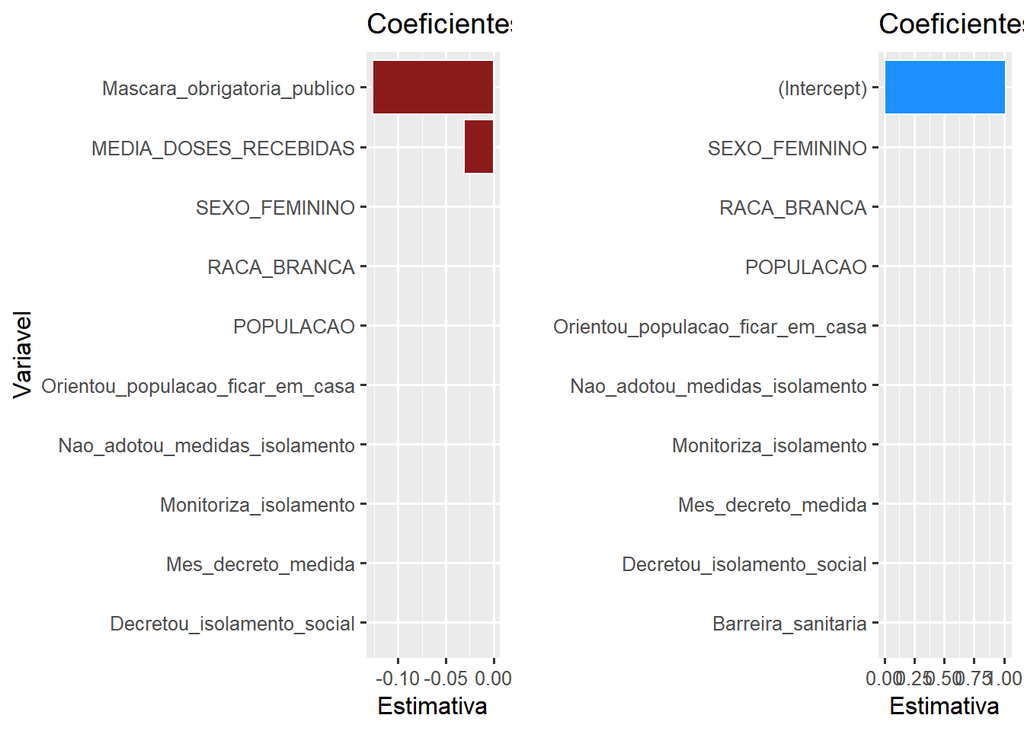

```r
theme_set(theme_gray(base_size = 12))
coefs_estimates = data.frame(Variavel = rownames(coefs_estimates),
                             Coeficientes = coefs_estimates[,1])
coef_pos = coefs_estimates %>% arrange(desc(Coeficientes))
coef_neg = coefs_estimates %>% arrange(Coeficientes)

graf_pos = ggplot(data = coef_pos[0:10,],
                  aes(x=reorder(Variavel, Coeficientes), y= Coeficientes))+
  geom_bar(stat="identity", col="white", fill="dodgerblue1")+
  coord_flip()+
  xlab("")+
  ylab("Estimativa")+
  ggtitle("Coeficientes Positivos")

graf_neg = ggplot(data = coef_neg[0:10,],
                  aes(x= reorder(Variavel, -Coeficientes), y=Coeficientes))+
  geom_bar(stat="identity", col="white", fill = "firebrick4")+
  coord_flip()+
  xlab("Variavel")+
  ylab("Estimativa")+
  ggtitle("Coeficientes Negativos")

ggarrange(graf_neg, graf_pos, ncol=2, nrow=1)
```

```r
library(FNN)
#install.packages("xgboost")
library(xgboost)
```

```r
library(rpart)
library(rpart.plot)
library(randomForest)
k.grid<- round(seq(1,50, length.out = 10))
erro<- rep(NA, length(k.grid))
for(ii in seq_along(k.grid)){
  predito<- knn.reg(train = train_matrix,
                    y=treinamento$PERCENTUAL_MEDIO_APLICADO,
                    k=k.grid[ii])$pred
  erro[ii]<- mean((predito-treinamento$PERCENTUAL_MEDIO_APLICADO)^2)
}
```

#Plot k.grid

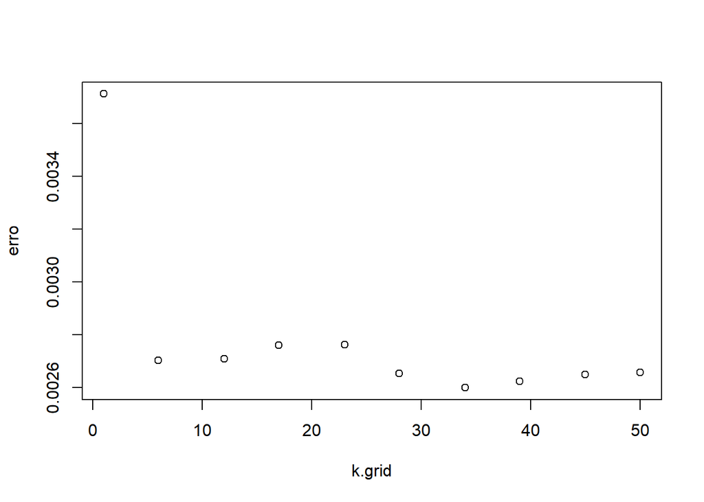

```r
plot(k.grid, erro)
```

```r
best.k<- k.grid[which.min(erro)]
predito_knn<- knn.reg(train = train_matrix,
                      test = test_matrix,
                      y= treinamento$PERCENTUAL_MEDIO_APLICADO,
                      k=best.k)$pred
riscos$knn<- (predito_knn-teste$PERCENTUAL_MEDIO_APLICADO)^2 %>% mean()
riscos
```

```
## $minimos.quadrados
## [1] 0.007624472
##
## $ridge
## [1] 0.00199383
##
## $lasso
## [1] 0.001997665
##
## $backward
## [1] 0.1264992
##
## $forward
## [1] 0.222074
##
## $knn
## [1] 0.002097424
```

#Árvore de regressão

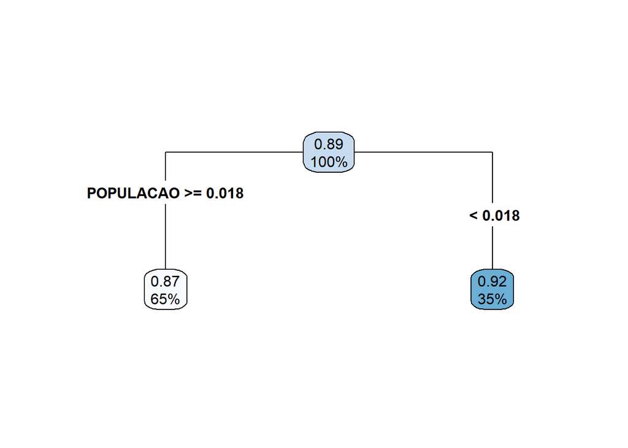

```r
arvore = rpart(PERCENTUAL_MEDIO_APLICADO~., data= treinamento)
melhorCp = arvore$cptable[which.min(arvore$cptable[,"xerror"]),
                          "CP"]
poda = prune(arvore, cp = melhorCp)

rpart.plot(poda, type=4)
```

```r
predito_arvore = predict(poda, teste)
riscos$arvores<- (predito_arvore-teste$PERCENTUAL_MEDIO_APLICADO)^2 %>% mean()
riscos$arvores
```

```
## [1] 0.002630716
```

#Florestas aleatórias

```r
floresta = randomForest(PERCENTUAL_MEDIO_APLICADO~.,
                        data = treinamento,
                        ntree = 100)

predito_floresta = predict(floresta, teste)

riscos$floresta<- (predito_floresta-teste$PERCENTUAL_MEDIO_APLICADO)^2 %>%  mean()
riscos$floresta
```

```
## [1] 0.002393126
```

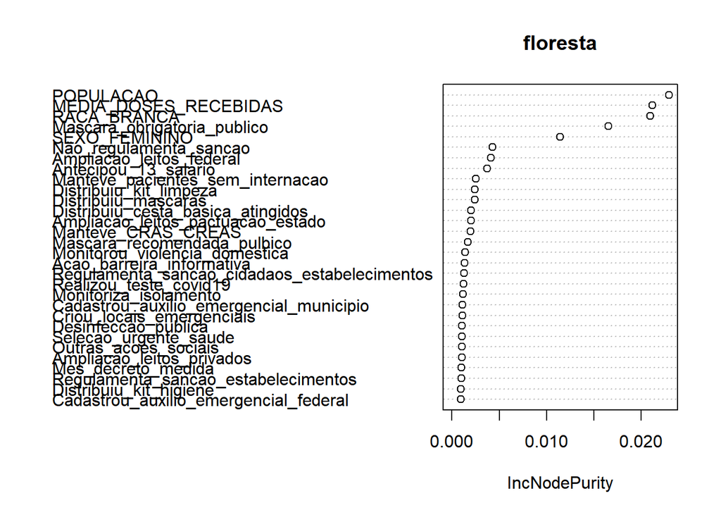

```r
varImpPlot(floresta)
```

#Boosting

```r
###############################################
xgb_model<- xgb.train(data= xgb.DMatrix(train_matrix, label = treinamento$PERCENTUAL_MEDIO_APLICADO),
                      nrounds = 50)
pred_xboost<- predict(xgb_model, test_matrix)
riscos$xgboost<- (pred_xboost-teste$PERCENTUAL_MEDIO_APLICADO)^2 %>% mean()
riscos$xgboost
```

```
## [1] 0.003147076
```

#Riscos

```r
riscos
```

```
## $minimos.quadrados
## [1] 0.007624472
##
## $ridge
## [1] 0.00199383
##
## $lasso
## [1] 0.001997665
##
## $backward
## [1] 0.1264992
##
## $forward
## [1] 0.222074
##
## $knn
## [1] 0.002097424
##
## $arvores
## [1] 0.002630716
##
## $floresta
## [1] 0.002393126
##
## $xgboost
## [1] 0.003147076
```

#Rede neurais

```
##              [,1]
##  [1,]  1.32837935
##  [2,]  0.99838013
##  [3,]  0.76732998
##  [4,]  1.98344535
##  [5,]  0.74172015
##  [6,]  0.90242816
##  [7,]  2.36292765
##  [8,]  0.88673825
##  [9,]  1.71574956
## [10,] -0.08895557
## [11,]  1.16361160
## [12,]  1.43637852
## [13,]  0.78958409
## [14,]  0.96803467
## [15,]  1.61851747
## [16,]  0.81930118
## [17,]  0.89919133
## [18,]  1.37087803
## [19,]  0.95178729
## [20,]  1.32962017
## [21,]  0.83838769
## [22,]  1.32047138
## [23,]  1.52590084
```

#RISCO FINAL DOS MODELOS

```
## $minimos.quadrados
## [1] 0.007624472
##
## $ridge
## [1] 0.00199383
##
## $lasso
## [1] 0.001997665
##
## $backward
## [1] 0.1264992
##
## $forward
## [1] 0.222074
##
## $knn
## [1] 0.002097424
##
## $arvores
## [1] 0.002630716
##
## $floresta
## [1] 0.002393126
##
## $xgboost
## [1] 0.003147076
##
## $rede_neural
## [1] 0.3259715
```